# Texto 2 - População Quilombola

Pablo Castro

19/06/2026

# 1 Introdução

A população quilombola constitui um dos grupos historicamente mais afetados pelas desigualdades estruturais no Brasil, especialmente no que se refere às condições de saúde, moradia, educação e acesso a serviços públicos. O Censo Demográfico de 2022, pela primeira vez, produziu informações em escala nacional sobre essa população, permitindo a elaboração de diagnósticos detalhados e territorialmente desagregados. Este texto integra o Produto 2 do contrato IC nº 000199/2025-0 e tem como objetivo caracterizar a população quilombola em três dimensões principais: estrutura etária, distribuição territorial e condições de vida, com foco especial em alfabetização e saneamento.

Ao longo do texto, são apresentados mapas e figuras que sintetizam padrões demográficos e socioeconômicos relevantes. A pirâmide etária evidencia diferenças marcantes entre a população quilombola e a população geral (Figura 2.1). Em seguida, são discutidas as concentrações territoriais da população quilombola e da população residente em territórios quilombolas (Figuras 3.1 e 3.2). A seção sobre alfabetização compara taxas entre quilombolas e população geral (Figuras 4.1 e 4.2), enquanto a última seção aborda desigualdades no acesso ao esgotamento sanitário (Figura 5.1). Juntos, esses indicadores fornecem um panorama inicial que será aprofundado nas próximas entregas da consultoria.

# 2 Estrutura etária da população quilombola

A análise da estrutura etária mostra que a população quilombola possui um perfil etário mais jovem em comparação à população brasileira como um todo. A Figura 2.1 mostra que, enquanto a população geral apresenta um processo mais avançado de envelhecimento — com uma base proporcionalmente menor e maior presença de pessoas idosas — a pirâmide etária quilombola mantém uma estrutura mais expansiva, característica de grupos populacionais sujeitos a desigualdades socioeconômicas persistentes.

Esse padrão reflete tanto diferenças nas condições de vida quanto desigualdades acumuladas ao longo das trajetórias sociais dessa população. A maior proporção de crianças e jovens entre quilombolas indica maiores taxas de fecundidade e, simultaneamente, menor sobrevivência às idades avançadas, fenômeno associado a restrições históricas de acesso a serviços de saúde, saneamento e políticas públicas universais.

## 2.1 Pirâmide etária – população quilombola e geral

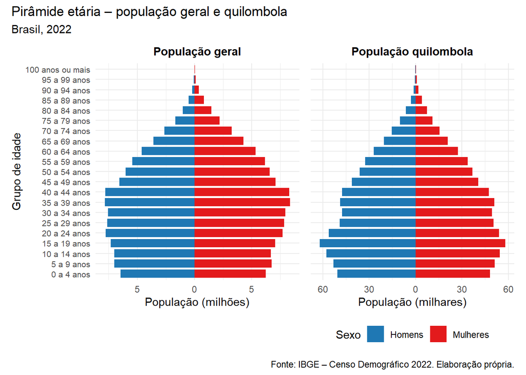

Figura 2.1: Pirâmide etária da população quilombola e da população geral, Brasil, 2022

A Figura 2.1 compara diretamente a pirâmide da população quilombola com a da população brasileira total. Entre os quilombolas, observa-se uma base mais larga, especialmente dos 0 aos 19 anos, evidenciando maior participação relativa de crianças, adolescentes e jovens. Já entre as idades acima de 60 anos, a população quilombola apresenta proporções significativamente menores que a população geral.

Essa diferença indica que os quilombolas enfrentam condições que reduzem a probabilidade de alcançar idades avançadas, como menor acesso a serviços de saúde, piores condições de moradia e maior exposição a riscos ambientais e sanitários. A presença reduzida de idosos quilombolas é um marcador importante das desigualdades estruturais que afetam essa população.

# 3 Distribuição territorial da população quilombola

A distribuição territorial da população quilombola (Figuras 3.1 e 3.2) revela forte concentração no Norte e Nordeste do país, especialmente em estados como Maranhão, Bahia, Pará e Pernambuco. Esses territórios coincidem com regiões historicamente marcadas pela presença de comunidades remanescentes de quilombos e por padrões persistentes de vulnerabilidade social e infraestrutura limitada.

Além disso, há diferenças relevantes entre a população quilombola total e aquela residente em territórios oficialmente reconhecidos como quilombos. A sobreposição parcial entre esses grupos reflete tanto processos de mobilidade quanto limitações no reconhecimento e regularização fundiária de territórios quilombolas. Esses padrões territoriais devem ser considerados no desenho de políticas públicas focalizadas e territorialmente sensíveis.

## 3.1 População quilombola e quilombola residente em quilombo por município

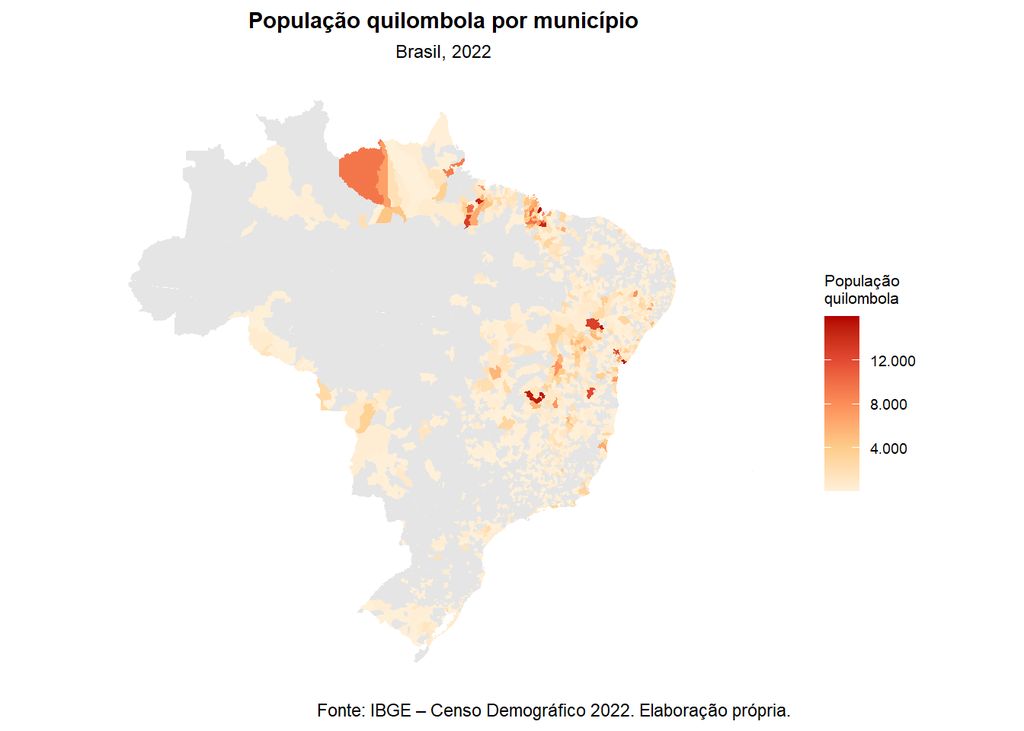

Figura 3.1: População quilombola por município – Brasil, 2022

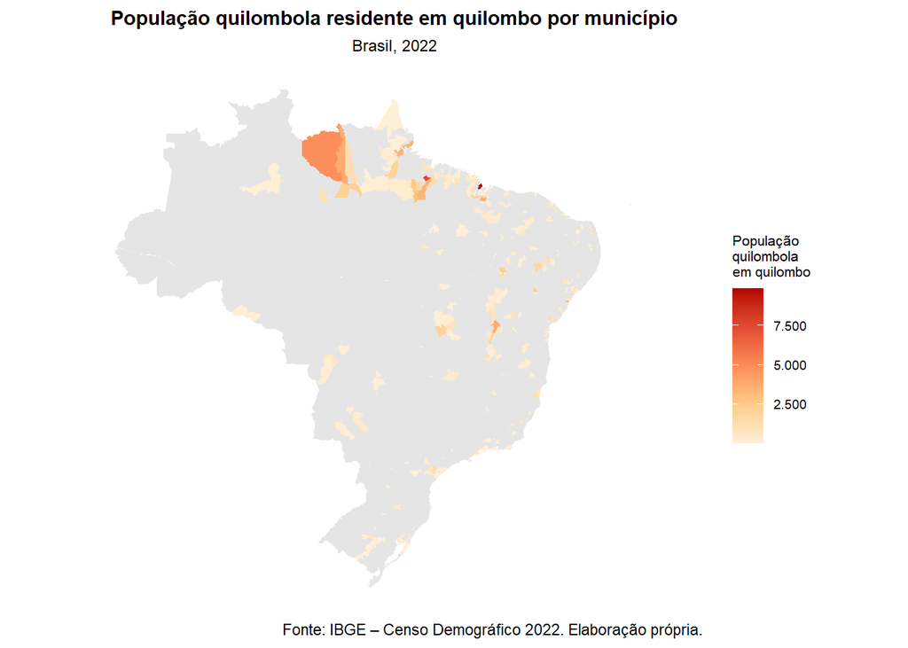

Figura 3.2: População quilombola residente em quilombo por município – Brasil, 2022

As Figuras 3.1 e 3.2 mostram que, embora a população quilombola esteja presente em praticamente todos os estados brasileiros, sua distribuição é altamente desigual. A Figura 3.1 evidencia municípios com grandes contingentes quilombolas, com destaque para o Maranhão e Bahia. Já a Figura 3.2, que apresenta apenas a população residente em territórios quilombolas, mostra maior concentração no Norte, especialmente no Pará, sugerindo forte presença de comunidades com território oficialmente reconhecido. Municípios sem presença quilombola registrada são exibidos em cinza.

O contraste entre os mapas indica que muitos quilombolas residem fora de territórios delimitados, reforçando a importância de políticas públicas que alcancem tanto comunidades reconhecidas quanto quilombolas residentes em áreas urbanas e rurais fora dos territórios tradicionais.

# 4 Alfabetização da população quilombola

Além disso, a Figura 4.2 mostra variações entre as Unidades da Federação, refletindo as desigualdades regionais mais amplas do país. As taxas de alfabetização quilombola são mais baixas nos estados com maiores déficits estruturais — especialmente no Nordeste e parte do Norte — indicando sobreposição entre desigualdade racial, territorial e educacional.

## 4.1 Taxa de alfabetização – Brasil geral e população quilombola, por sexo

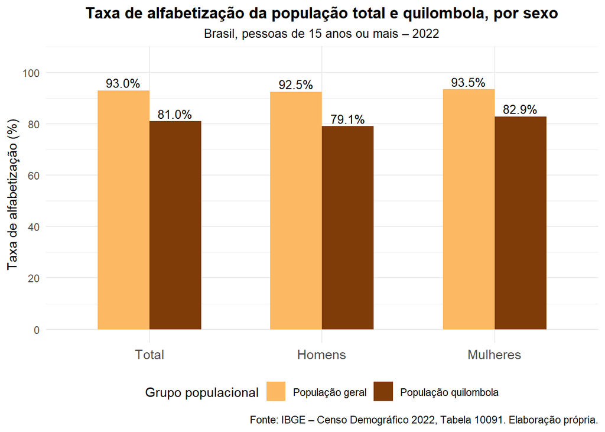

Figura 4.1: Taxa de alfabetização da população total e quilombola, por sexo – Brasil, 2022

A Figura 4.1 mostra que a taxa de alfabetização da população quilombola é inferior à da população geral em todos os grupos analisados. Entre pessoas de 15 anos ou mais, a taxa geral é de 93%, enquanto entre quilombolas é de 81%. Entre homens quilombolas, a taxa é ainda mais baixa (79,1%), refletindo desigualdades de gênero combinadas com vulnerabilidades raciais e territoriais.

Mulheres quilombolas apresentam taxa de alfabetização ligeiramente superior à dos homens (82,9%), mas ainda assim muito abaixo da taxa observada para mulheres da população geral. Esse padrão reforça que as desigualdades enfrentadas pela população quilombola são estruturais e afetam todos os segmentos da população.

## 4.2 Taxa de alfabetização da população quilombola por UF

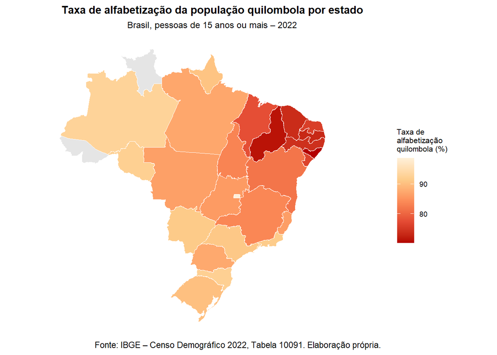

Figura 4.2: Taxa de alfabetização da população quilombola por UF – Brasil, 2022

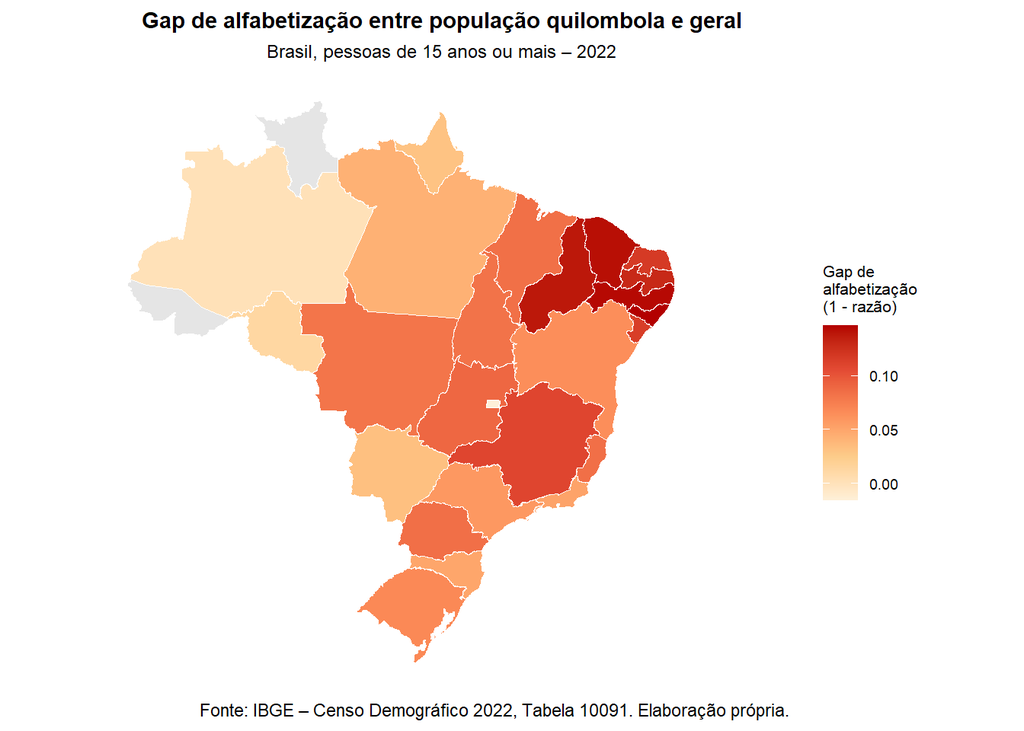

Figura 4.3: Gap de alfabetização entre a população quilombola e a população geral por UF – Brasil, 2022

# 5 Condições de saneamento em domicílios com população quilombola

As condições de saneamento são determinantes fundamentais para saúde, longevidade e bem-estar. Entre domicílios com moradores quilombolas, a Figura 5.1 mostra que o acesso ao esgotamento sanitário adequado é significativamente mais limitado, tanto em áreas urbanas quanto, especialmente, nas áreas rurais.

Essas desigualdades reforçam um padrão histórico: maior vulnerabilidade ambiental e sanitária para a população quilombola, frequentemente localizada em territórios sem infraestrutura adequada e sujeita a múltiplas privações.

## 5.1 Domicílios com moradores quilombolas e esgotamento inadequado – total, urbano e rural

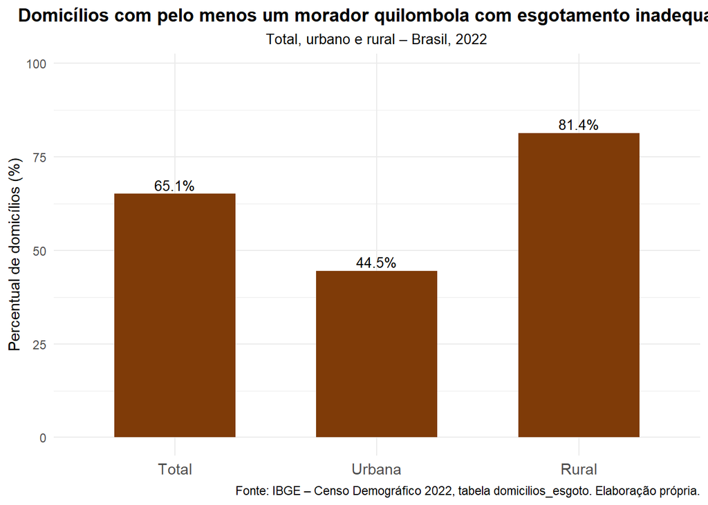

Figura 5.1: Percentual de domicílios com moradores quilombolas com esgotamento inadequado – total, urbano e rural, Brasil, 2022

A Figura 5.1 mostra que **65,1%** dos domicílios com moradores quilombolas possuem esgotamento inadequado, valor muito superior à média nacional. Nas áreas rurais, a situação é ainda mais crítica: **81,4%** dos domicílios quilombolas rurais têm saneamento inadequado. Mesmo nas áreas urbanas, onde a infraestrutura costuma ser mais disponível, **44,5%** dos domicílios quilombolas enfrentam esgotamento inadequado.

Esses resultados dialogam diretamente com os achados sobre alfabetização e estrutura etária. A precariedade sanitária afeta condições de saúde ao longo do ciclo de vida, contribuindo para menores níveis de escolaridade e menor sobrevivência até idades avançadas entre quilombolas.

# 6 Considerações finais

Os resultados apresentados neste texto mostram que a população quilombola enfrenta desigualdades estruturais profundas em múltiplas dimensões. A pirâmide etária indica menor sobrevivência em idades avançadas, sugerindo vulnerabilidades acumuladas ao longo do ciclo de vida. A distribuição territorial revela forte concentração em regiões historicamente marcadas por pobreza estrutural e limitações de infraestrutura.

Os indicadores educacionais reforçam essas desigualdades: a taxa de alfabetização quilombola permanece muito inferior à da população geral, com variações regionais que seguem os padrões de desigualdade do país. Por fim, os resultados de saneamento evidenciam que a maioria dos domicílios quilombolas vive sem acesso adequado ao esgotamento sanitário, com impacto direto sobre saúde, escolaridade e longevidade.

Esses achados evidenciam a urgência de políticas específicas, territorialmente orientadas e intersetoriais. O Decreto nº 11.786/2023, que reorganizou a estrutura do Ministério da Igualdade Racial, reforçou o marco normativo para a proteção dos direitos quilombolas, mas os dados do Censo 2022 mostram que a implementação efetiva dessas políticas ainda enfrenta grandes desafios. Nesse sentido, recomenda-se: (i) priorizar a expansão de infraestrutura de saneamento básico nos territórios quilombolas rurais, onde mais de 80% dos domicílios carecem de esgotamento adequado; (ii) intensificar programas de alfabetização voltados a adultos quilombolas, especialmente nos estados do Nordeste e do Norte; (iii) fortalecer a articulação com o SINAPIR — Sistema Nacional de Promoção da Igualdade Racial — para garantir que os indicadores quilombolas sejam incorporados ao monitoramento das políticas estaduais e municipais; e (iv) aprofundar, nas próximas entregas, as dimensões de trabalho, renda e saúde da população quilombola, complementando o panorama aqui apresentado.